# Here Comes the Sun: The Effect of Earlier Sunrises and Sunsets on Academic Achievement

Hannah M. Stackpole

## Intro & Literature TL;DR

- permanent DST proposals
- DST moves a location one time zone father east (later sunrises/sunsets)
- Can look at time zone borders to see the effects of different sunrise/sunset times
- Later sunsets result in less sleep and more disease (Giuntella & Mazzona, 2019)
- Later school starts (better for adolescents) result in higher grades, more time on HW, less time on TV, less day-time sleepiness, fewer depressive symptoms (Carrell, 2011; Edwards, 2012; Heissell & Norris, 2018; Wahlstrom, 2002; 2017)
- **My research**: looks at Indiana counties that moved from Eastern to Central time in 2006

## Conceptual Model

- Three clocks: sun, body, social (Roenneberg et al., 2019)
- Sunsets & sleep timing: especially important for adolescents
- Sleep & test scores
  - Less sleep (chronic sleep deprivation)
  - Later sunrises (drowsy in mornings)
- Long term implications: human capital, wages, and life outcomes (Becker, 1964; Mincer, 1974; Card, 2000; Hanushek & Woessmann, 2008; 2012; Chetty et al., 2014; Mulligan et al., 1999; Murnane et al., 1995; 2000).
  - educational achievement matters (not just attainment)

## Data

- **Indiana Department of Education: Academic outcomes (% proficient grades 3-10)**
- Indiana Department of Education: Corporation-level demographic data, graduation rates, and attendance rates
- U.S. Census Bureau’s Annual Survey of School System Finances: District-level revenues and expenditures
- U.S. Census Bureau Small Area Income and Poverty Estimates (SAIPE): County level MHI & poverty
- Bureau of Labor Statistics (BLS) Local Area Unemployment Statistics (LAUS): Counly level unemployment
- U.S. Census Bureau’s Intercensal Estimates: County population

## Empirical Framework

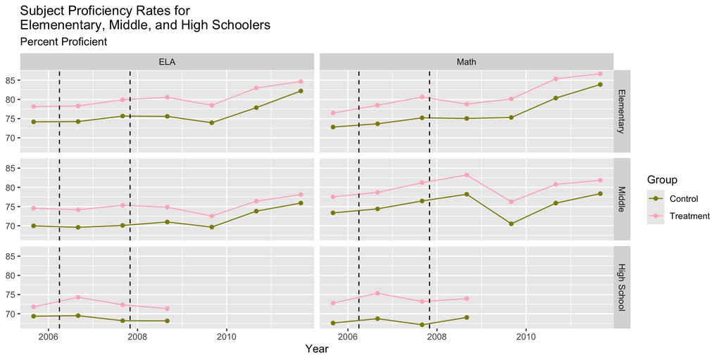

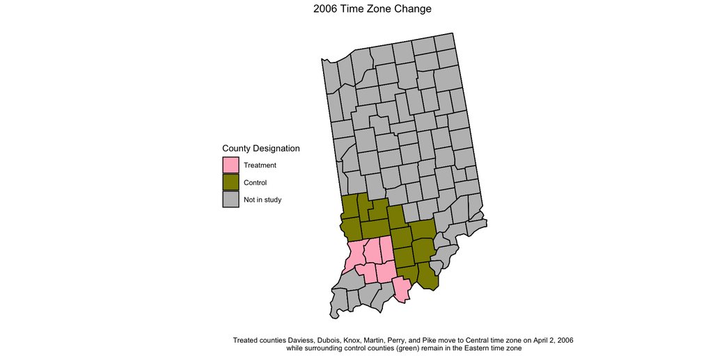

- Economists’ favorite: DiD
- ${Y}_{itg} = \beta_1(\text{treated}_{ig} \times \text{post_treat}_t) + \alpha_i + \gamma_t + \delta_g + \varepsilon_{itg}$
- treatment counties move to Central time zone in April 2006

## Main Results

| age_range | ELA Estimate (SE) | ELA p-value | ELA Holm p | Math Estimate (SE) | Math p-value | Math Holm p |
| --- | --- | --- | --- | --- | --- | --- |
| All Grades | 0.008 (0.01) | 0.257 | 0.534 | 0.010 (0.01) | 0.187 | 0.747 |
| Elementary | -0.001 (0.01) | 0.947 | 0.947 | 0.014 (0.01) | 0.238 | 0.747 |
| Middle | 0.015 (0.01) | 0.178 | 0.534 | 0.011 (0.01) | 0.282 | 0.747 |
| High School | 0.027 (0.01) | 0.042 | 0.169 | 0.003 (0.01) | 0.820 | 0.820 |

- basically nothing (potential effects in ELA/HS)
- ELA estimates increase as age increases which is consistent with the literature and my hypothesis

# Heterogeneous Effects

| prof_level | ELA Estimate (SE) | ELA p-value | ELA Holm p | Math Estimate (SE) | Math p-value | Math Holm p |
| --- | --- | --- | --- | --- | --- | --- |
| All Grades |  |  |  |  |  |  |
| very low | 0.042 (0.01) | 0.002 | 0.035 | 0.020 (0.02) | 0.302 | 1.000 |
| low | 0.027 (0.01) | 0.071 | 0.886 | 0.019 (0.01) | 0.100 | 1.000 |
| high | 0.008 (0.01) | 0.392 | 1.000 | 0.022 (0.01) | 0.118 | 1.000 |
| very high | 0.000 (0.01) | 0.999 | 1.000 | 0.009 (0.01) | 0.409 | 1.000 |
| Elementary |  |  |  |  |  |  |
| very low | 0.021 (0.02) | 0.208 | 1.000 | 0.057 (0.02) | 0.006 | 0.104 |
| low | 0.059 (0.04) | 0.128 | 1.000 | 0.016 (0.02) | 0.472 | 1.000 |
| high | 0.003 (0.01) | 0.845 | 1.000 | 0.025 (0.02) | 0.179 | 1.000 |
| very high | 0.004 (0.01) | 0.796 | 1.000 | 0.001 (0.02) | 0.959 | 1.000 |
| Middle |  |  |  |  |  |  |
| very low | 0.060 (0.03) | 0.026 | 0.387 | -0.007 (0.03) | 0.800 | 1.000 |
| low | 0.007 (0.02) | 0.728 | 1.000 | 0.011 (0.03) | 0.698 | 1.000 |
| high | 0.015 (0.02) | 0.383 | 1.000 | 0.020 (0.01) | 0.152 | 1.000 |
| very high | 0.003 (0.02) | 0.899 | 1.000 | 0.025 (0.01) | 0.067 | 0.940 |
| High School |  |  |  |  |  |  |
| very low | 0.054 (0.02) | 0.040 | 0.561 | -0.009 (0.03) | 0.753 | 1.000 |
| low | 0.040 (0.02) | 0.068 | 0.886 | 0.036 (0.02) | 0.048 | 0.726 |
| high | 0.031 (0.02) | 0.191 | 1.000 | 0.002 (0.02) | 0.942 | 1.000 |
| very high | -0.027 (0.02) | 0.294 | 1.000 | -0.003 (0.03) | 0.899 | 1.000 |

- I went a bit overboard lol -> p-val corrections :(
- **ELA / All / Very Low** & ELA / Low / V Low promising; consistent with Edwards (2012)

# Conclusion?

- may or may not be anything here
- limited data and ability to establish pre-treatment parallel trends
- would have liked to do more and am still working :/